# Assignment 1 Exploratory Data Analysis

Xavier Vílchez (xavier.vilchez01@estudiant.upf.edu)

Last update: 04 March, 2025

# Analysis of the Heart Disease Dataset

Load the data from [here](https://raw.githubusercontent.com/jpinero/DMI_2021/main/datasets/heart_disease_dataset.csv), and the description is [here](https://raw.githubusercontent.com/jpinero/DMI_2021/main/datasets/heart_disease_description.txt). The original dataset comes from [here](https://archive.ics.uci.edu/ml/datasets/Heart+Disease) and corresponds to the [processed cleveland data](https://archive.ics.uci.edu/ml/machine-learning-databases/heart-disease/processed.cleveland.data)

## Perform an EDA on the dataset

```r
# Load necessary libraries
library(mice)
library(GGally)
library(DataExplorer)
library(SmartEDA)
library(vtable)
library(mlbench)
library(ggplot2)
library(tidyr)
library(dplyr)
library(reshape2)
library(ggpubr)
library(rcompanion)
library(corrplot)
library(readxl)
library(gridExtra)
library(grid)
library(ggplotify)
library(patchwork)
library(naniar)
library(ComplexHeatmap)
library(circlize)
library(tibble)
library(viridis)
```

```r
# Load the dataset
data <- read.table("./data/raw_data/heart_disease_dataset.csv", na.strings = "?", header = TRUE)

# Convert appropriate columns to factors for categorical variables
factor_columns <- c("sex", "cp", "fbs", "restecg", "exang", "slope", "ca", "thal", "num")
data[factor_columns] <- lapply(data[factor_columns], as.factor)

# 1. Data summary reports
# Generate summaries using vtable
vtable(data)
```

data

| Name | Class | Values |
| --- | --- | --- |
| age | integer | Num: 29 to 77 |
| sex | factor | ‘0’ ‘1’ |
| cp | factor | ‘1’ ‘2’ ‘3’ ‘4’ |
| trestbps | integer | Num: 94 to 200 |
| chol | integer | Num: 126 to 564 |
| fbs | factor | ‘0’ ‘1’ |
| restecg | factor | ‘0’ ‘1’ ‘2’ |
| thalach | integer | Num: 71 to 202 |
| exang | factor | ‘0’ ‘1’ |
| oldpeak | numeric | Num: 0 to 6.2 |
| slope | factor | ‘1’ ‘2’ ‘3’ |
| ca | factor | ‘0’ ‘1’ ‘2’ ‘3’ |
| thal | factor | ‘3’ ‘6’ ‘7’ |
| num | factor | ‘0’ ‘1’ ‘2’ ‘3’ ‘4’ |
| patient_id | integer | Num: 1 to 303 |

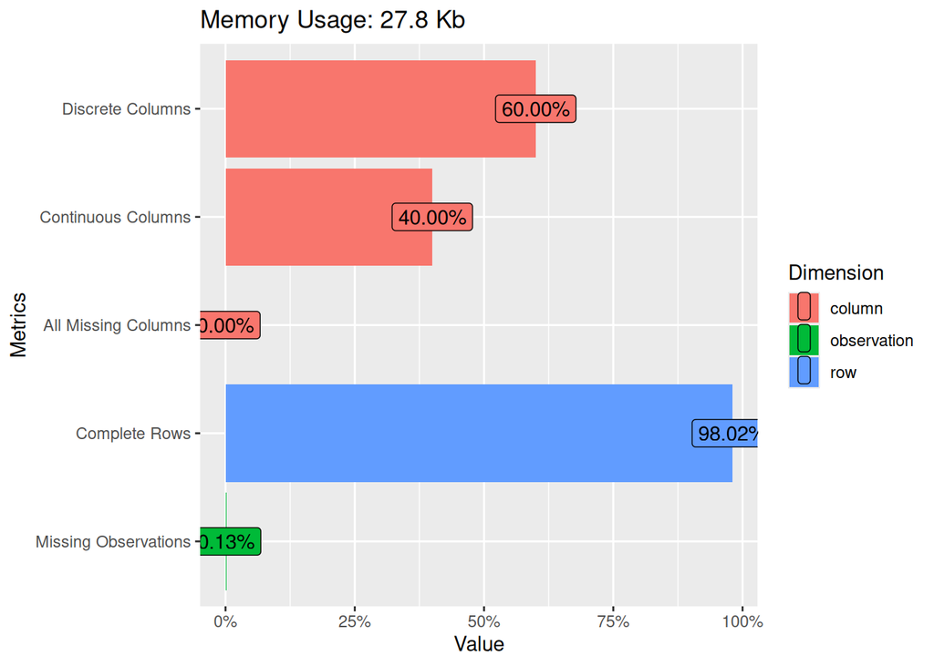

```r
#Check the quality of the data
plot_intro(data)
```

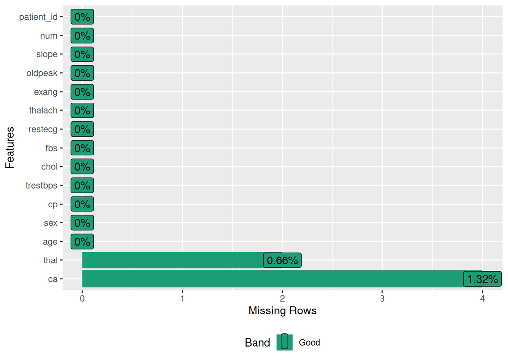

```r
# 2. Check for missing values
# Visualize missing data
plot_missing(data)
```

The dataset contains clinical data from 303 patients with 15 variables related to heart disease or health.

As we can see, we have almost no NAs in the dataset, but we will try to impute them using the Mice package.

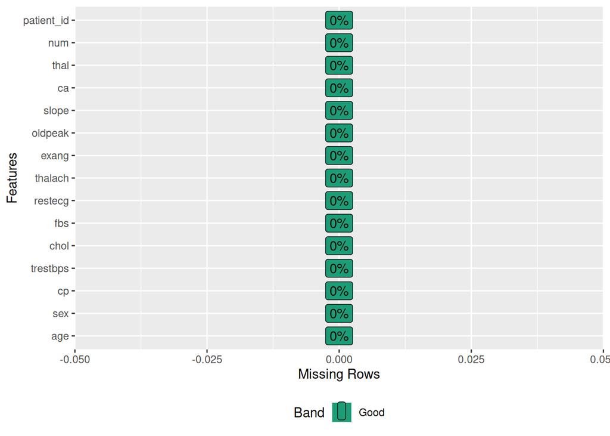

```r
# Handle missing values using mice
if (anyNA(data)) {
  invisible(capture.output({
      mice_output <- mice(data, m = 1, method = 'pmm', seed = 1)
  data_imputed <- complete(mice_output, 1) # Use the first imputed dataset
    }))
}

# Check if it's okay
plot_missing(data_imputed)
```

The imputation process has been successful, now we will tackle the outlier detection.

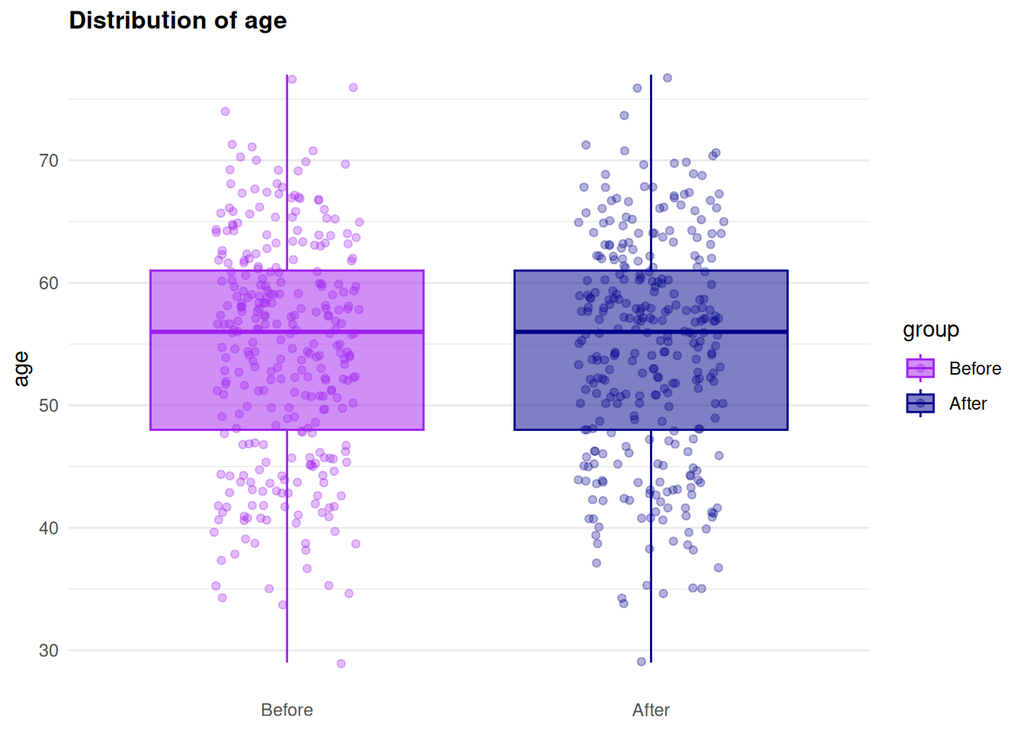

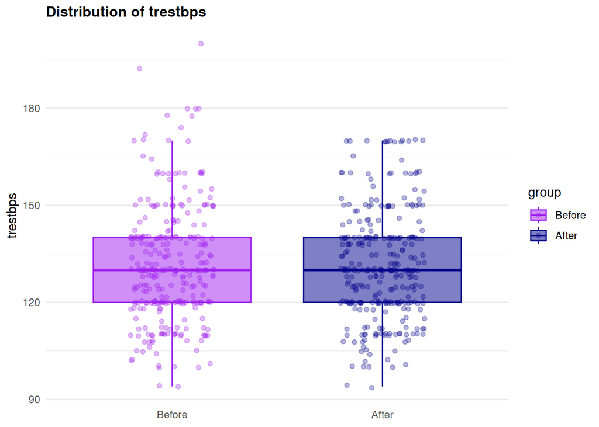

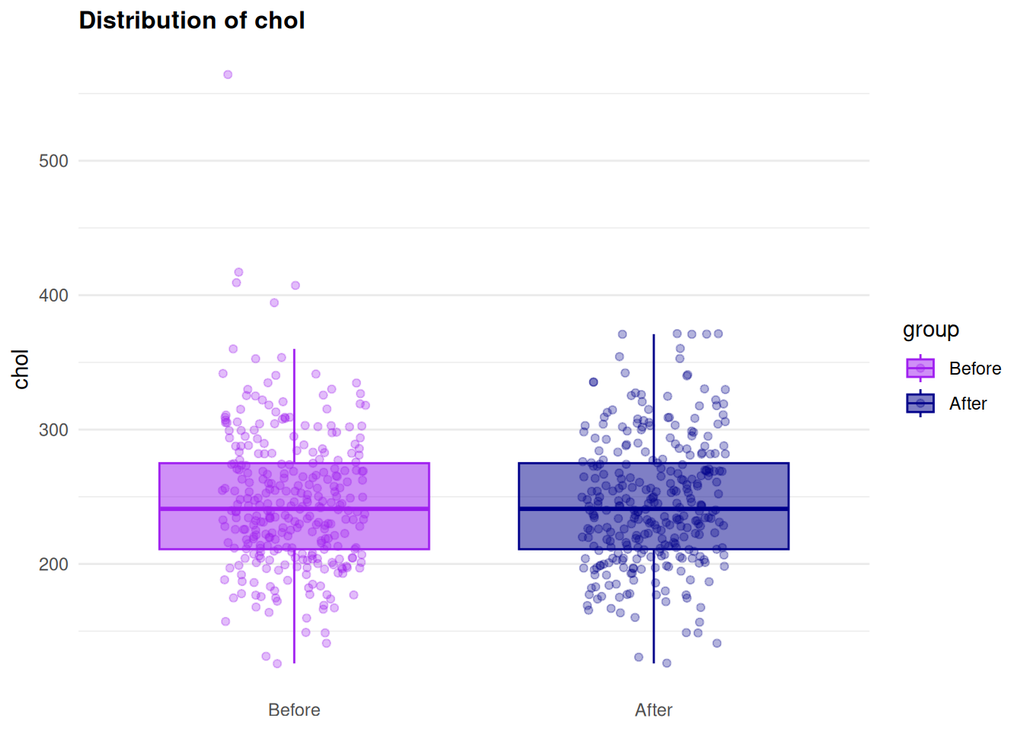

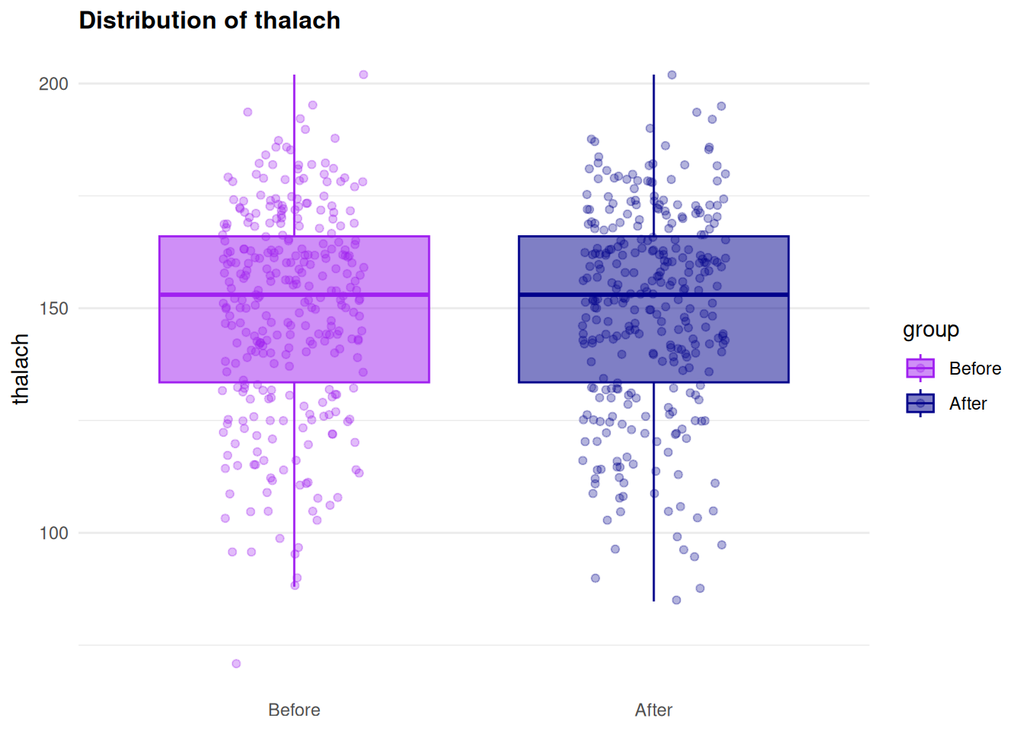

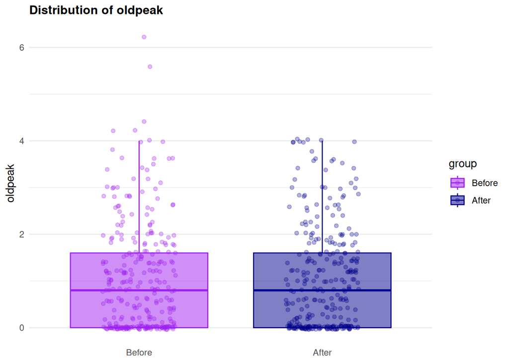

```r
# Identify numerical columns, ignoring the ID column
numerical_columns <- setdiff(names(data_imputed), c("patient_id", factor_columns))

# Update the 'sex' variable to use "Male" and "Female" instead of 1 and 0
data_imputed$sex <- factor(data_imputed$sex, levels = c(0, 1), labels = c("Female", "Male"))

# 3. Outliers detection and replacement

# Detect and replace outliers
data_cleaned <- data_imputed
replace_outliers <- function(column_name) {
  column <- data_cleaned[[column_name]]
  if (is.numeric(column)) {
    Q1 <- quantile(column, 0.25)
    Q3 <- quantile(column, 0.75)
    IQR <- Q3 - Q1
    upper_limit <- Q3 + 1.5 * IQR
    lower_limit <- Q1 - 1.5 * IQR
    data_cleaned[[column_name]] <<- ifelse(column > upper_limit, upper_limit, ifelse(column < lower_limit, lower_limit, column))
  }
}

# Box plots for numerical variables
# Apply the function to the numerical columns
invisible(lapply(numerical_columns, replace_outliers))

# Function to create comparison box plots before and after outliers replacement
create_comparison_boxplots <-function(data_before, data_after, numerical_columns) {
  #Create a list to store all plots
  plot_list <- list()

  for (col in numerical_columns) {
    # Prepare data for plotting
    df_combined <- data.frame(
      value = c(data_before[[col]], data_after[[col]]),
      group = factor(rep(c("Before", "After"), each = nrow(data_before)),
                     levels = c("Before", "After")),
      variable = col
    )
    # Create plot
    p <- ggplot(df_combined, aes(x = group, y = value, fill = group, color = group)) +
      # Add boxplot
      geom_boxplot(alpha = 0.5, outlier.shape = NA) +
      # Add jittered points
      geom_jitter(width = 0.2, alpha = 0.3) +
      # Set colors
      scale_fill_manual(values = c("Before" = "purple", "After" = "darkblue")) +
      scale_color_manual(values = c("Before" = "purple", "After" = "darkblue")) +
      # Customize theme
      theme_minimal() +
      theme(
        plot.title = element_text(size = 12, face = "bold"),
        axis.title.x = element_blank(),
        panel.grid.major.x = element_blank()
      ) +
      # Add labels
      labs(title = paste("Distribution of", col), y = col) + xlab(col)
    plot_list[[col]] <- p
  }
  return(plot_list)
}

#Create all plots
plots <- create_comparison_boxplots(data_imputed, data_cleaned, numerical_columns)
plots
```

```r
# Save the processed and imputed dataset
write.csv(data_cleaned, "./data/processed_data/heart_disease_dataset_cleaned.csv", row.names = FALSE)
```

With the clean dataset, we can now perform an EDA, starting with the univariate analysis for continuous and categorical variables.

```r
# 4. Univariate summaries

summary(data_cleaned[numerical_columns])
```

```
##       age           trestbps          chol          thalach
##  Min.   :29.00   Min.   : 94.0   Min.   :126.0   Min.   : 84.75
##  1st Qu.:48.00   1st Qu.:120.0   1st Qu.:211.0   1st Qu.:133.50
##  Median :56.00   Median :130.0   Median :241.0   Median :153.00
##  Mean   :54.44   Mean   :131.3   Mean   :245.6   Mean   :149.65
##  3rd Qu.:61.00   3rd Qu.:140.0   3rd Qu.:275.0   3rd Qu.:166.00
##  Max.   :77.00   Max.   :170.0   Max.   :371.0   Max.   :202.00
##     oldpeak
##  Min.   :0.000
##  1st Qu.:0.000
##  Median :0.800
##  Mean   :1.024
##  3rd Qu.:1.600
##  Max.   :4.000
```

```r
# Function to create a combined frequency table for all categorical variables
create_combined_freq_table <- function(data, factor_columns) {
  # Initialize an empty data frame to store all results
  all_frequencies <- list()

  # Process each factor column in order
  for (col in factor_columns) {
    # Calculate frequencies
    freq <- table(data[[col]])
    rel_freq <- prop.table(freq) * 100

    #Create data frame for this variable
    freq_df <- data.frame(
      Variable = col,
      Category = names(freq),
      Frequency = as.numeric(freq),
      Percentage = round(as.numeric(rel_freq), 2)
    )
    # Append to the main data frame
    all_frequencies[[col]] <- freq_df
  }
  all_frequencies <- do.call(rbind, all_frequencies)

  # Create nice looking table with kableExtra
  kable(all_frequencies,
        format = "html",
        caption = "Frequency distribution of categorical variables") %>%
    kable_styling(bootstrap_options = c("striped", "hover", "condensed"), full_width = FALSE)
}

# Create and display the combined frequency table
combined_freq_table <- create_combined_freq_table(data_cleaned, factor_columns)
combined_freq_table
```

Frequency distribution of categorical variables

|  | Variable | Category | Frequency | Percentage |
| --- | --- | --- | --- | --- |
| sex.1 | sex | Female | 97 | 32.01 |
| sex.2 | sex | Male | 206 | 67.99 |
| cp.1 | cp | 1 | 23 | 7.59 |
| cp.2 | cp | 2 | 50 | 16.50 |
| cp.3 | cp | 3 | 86 | 28.38 |
| cp.4 | cp | 4 | 144 | 47.52 |
| fbs.1 | fbs | 0 | 258 | 85.15 |
| fbs.2 | fbs | 1 | 45 | 14.85 |
| restecg.1 | restecg | 0 | 151 | 49.83 |
| restecg.2 | restecg | 1 | 4 | 1.32 |
| restecg.3 | restecg | 2 | 148 | 48.84 |
| exang.1 | exang | 0 | 204 | 67.33 |
| exang.2 | exang | 1 | 99 | 32.67 |
| slope.1 | slope | 1 | 142 | 46.86 |
| slope.2 | slope | 2 | 140 | 46.20 |
| slope.3 | slope | 3 | 21 | 6.93 |
| ca.1 | ca | 0 | 179 | 59.08 |
| ca.2 | ca | 1 | 66 | 21.78 |
| ca.3 | ca | 2 | 38 | 12.54 |
| ca.4 | ca | 3 | 20 | 6.60 |
| thal.1 | thal | 3 | 168 | 55.45 |
| thal.2 | thal | 6 | 18 | 5.94 |
| thal.3 | thal | 7 | 117 | 38.61 |
| num.1 | num | 0 | 164 | 54.13 |
| num.2 | num | 1 | 55 | 18.15 |
| num.3 | num | 2 | 36 | 11.88 |
| num.4 | num | 3 | 35 | 11.55 |
| num.5 | num | 4 | 13 | 4.29 |

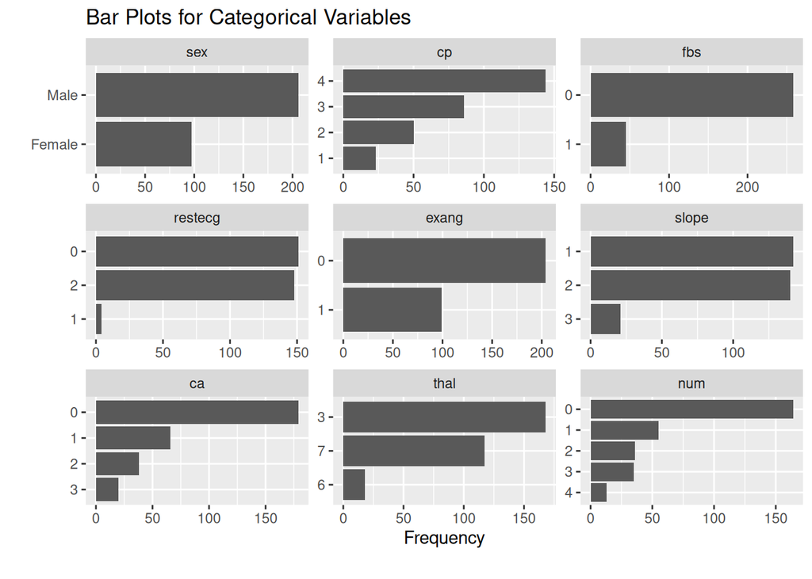

```r
# Plot univariate distributions
plot_bar(data_cleaned[factor_columns], title = "Bar Plots for Categorical Variables")
```

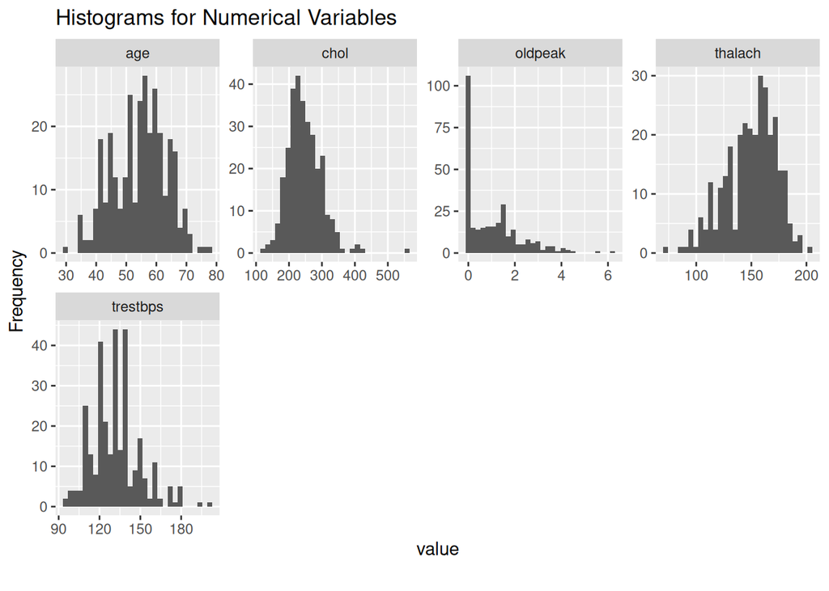

```r
plot_histogram(data[ , numerical_columns], title = "Histograms for Numerical Variables")
```

From the barplots we can see that the sex ratio is imbalanced in this study, as for the rest of the variables, we see that most of the patients have low levels of the possible biomarkers for having heart disease and that they actually doesn’t show any symptoms related with heart disease (represented by the increase in the factor num).

Now, we will proceed with the bivariate analysis.

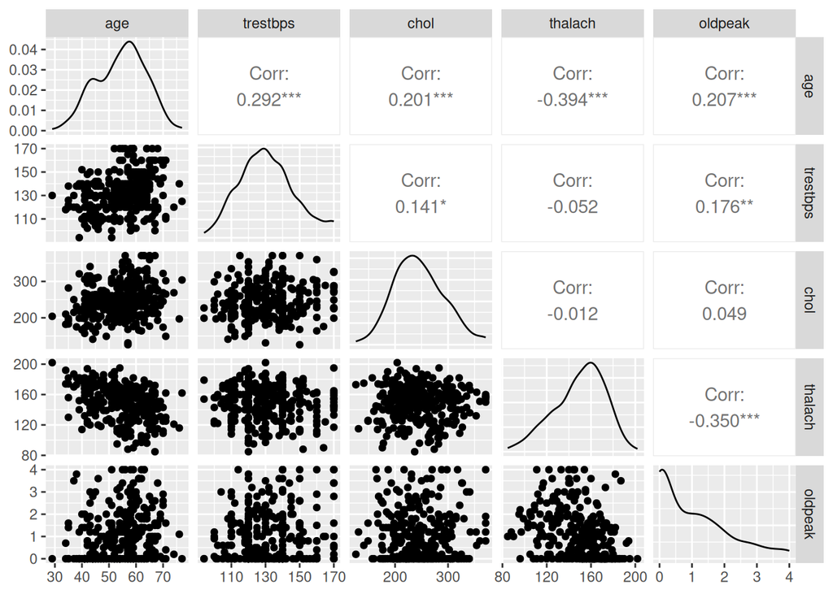

```r
# 5. Bivariate analysis
# Pairwise scatter plots and correlation for numerical variables
ggpairs(data_cleaned, columns = c("age", "trestbps", "chol", "thalach", "oldpeak"))
```

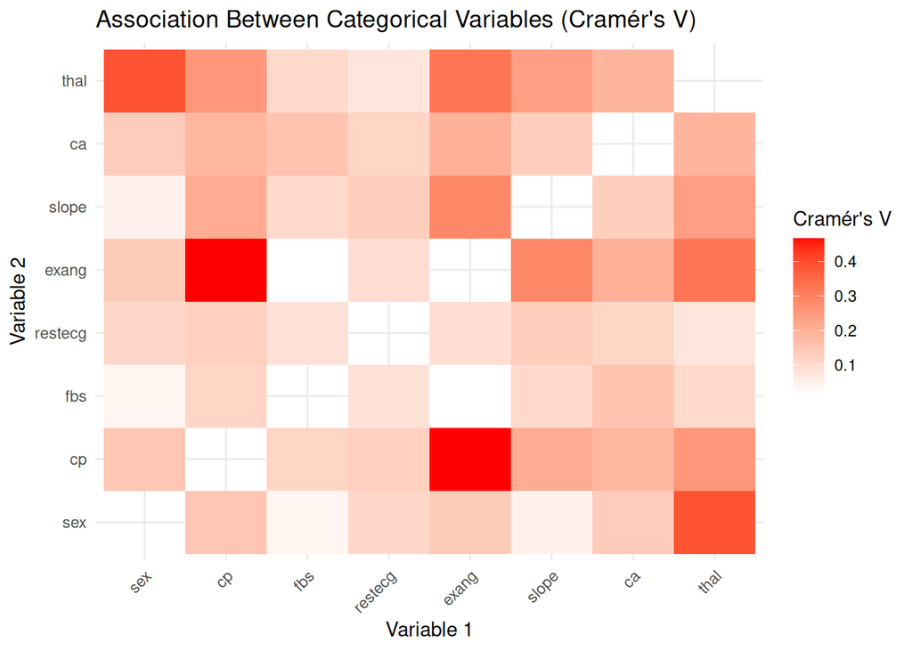

```r
# Function to compute Cramér's V
cramers_v <- function(x, y) {
  tbl <- table(x, y)
  chisq <- chisq.test(tbl)
  n <- sum(tbl)
  phi2 <- chisq$statistic / n
  k <- min(ncol(tbl), nrow(tbl))
  return(sqrt(phi2 / (k - 1)))
}

# Compute Cramér's V for all categorical variable pairs
factor_vars <- factor_columns[factor_columns != "num"]
cramers_matrix <- matrix(NA, nrow = length(factor_vars), ncol = length(factor_vars),
                         dimnames = list(factor_vars, factor_vars))

for (i in 1:length(factor_vars)) {
  for (j in 1:length(factor_vars)) {
    if (i != j) {
      cramers_matrix[i, j] <- cramers_v(data_cleaned[[factor_vars[i]]], data_cleaned[[factor_vars[j]]])
    } else {
      cramers_matrix[i, j] <- NA  # Hide diagonal
    }
  }
}

# Convert to long format for ggplot
cramers_df <- melt(cramers_matrix, na.rm = TRUE)  # Remove NA values (diagonal)

# Plot heatmap without diagonal
ggplot(cramers_df, aes(x = Var1, y = Var2, fill = value)) +
  geom_tile() +
  scale_fill_gradient(low = "white", high = "red", na.value = "white") +
  labs(title = "Association Between Categorical Variables (Cramér's V)",
       x = "Variable 1", y = "Variable 2", fill = "Cramér's V") +
  theme_minimal() +
  theme(axis.text.x = element_text(angle = 45, hjust = 1))
```

From the bivariate continuous analysis, we can see that age has significant correlation with all the other variables.

As for the categorical variables, we have used Cramer’s V test to see which variables are more related to each other, and we can see that the most related pairs are sex-thal and exang-cp.

## Create visualizations in order to show which variables seem to be more associated with heart disease

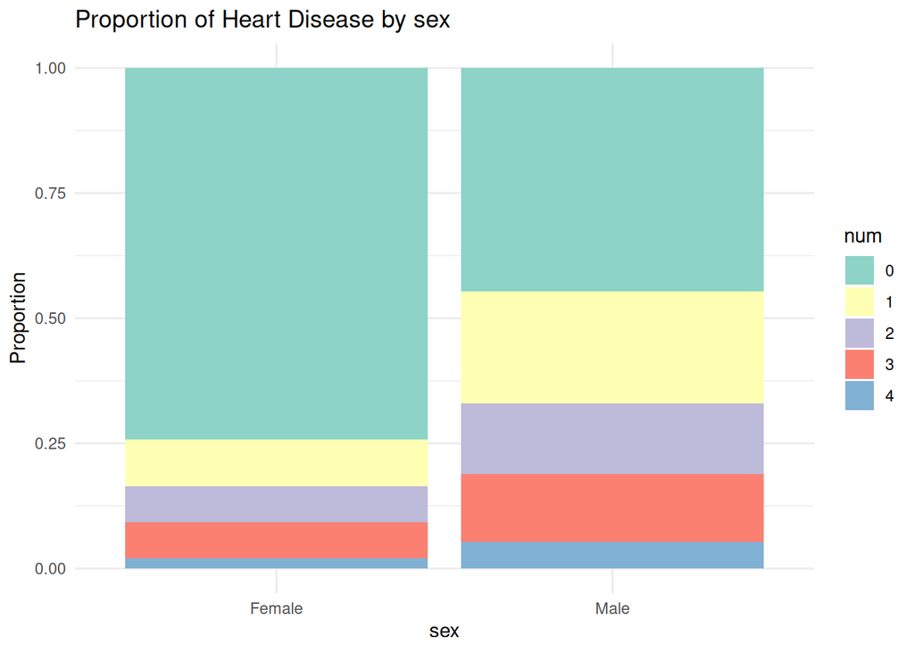

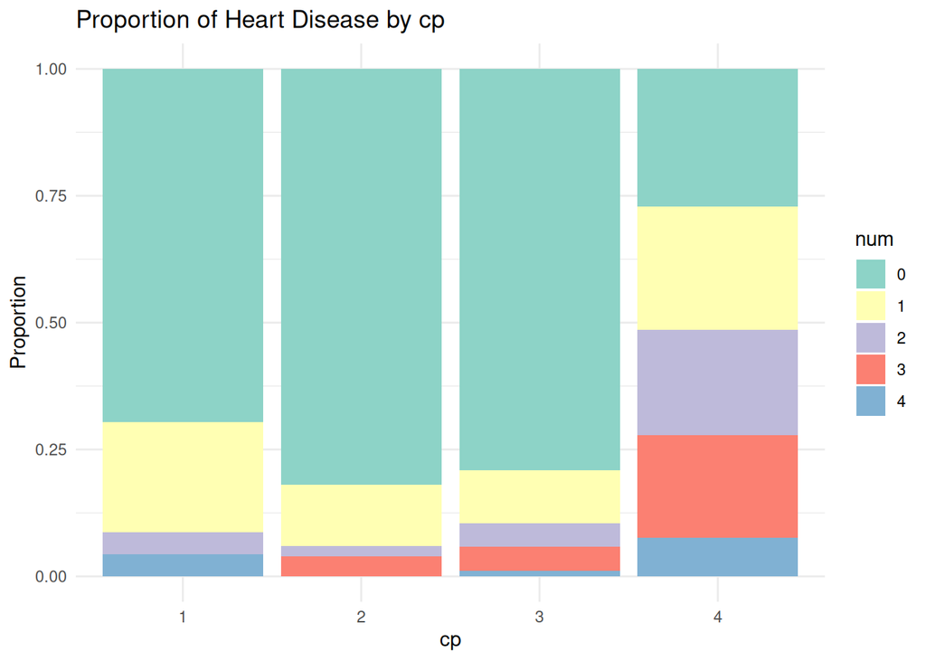

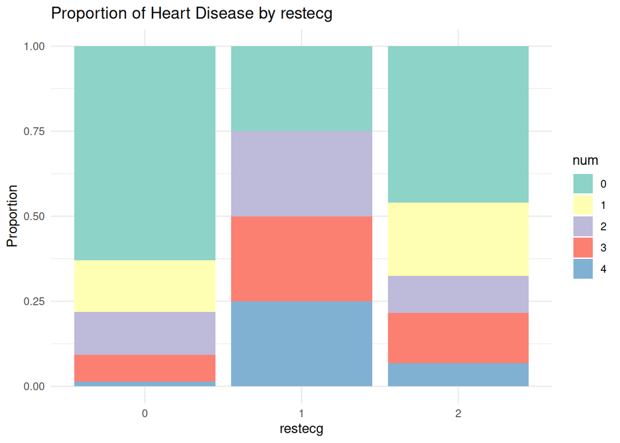

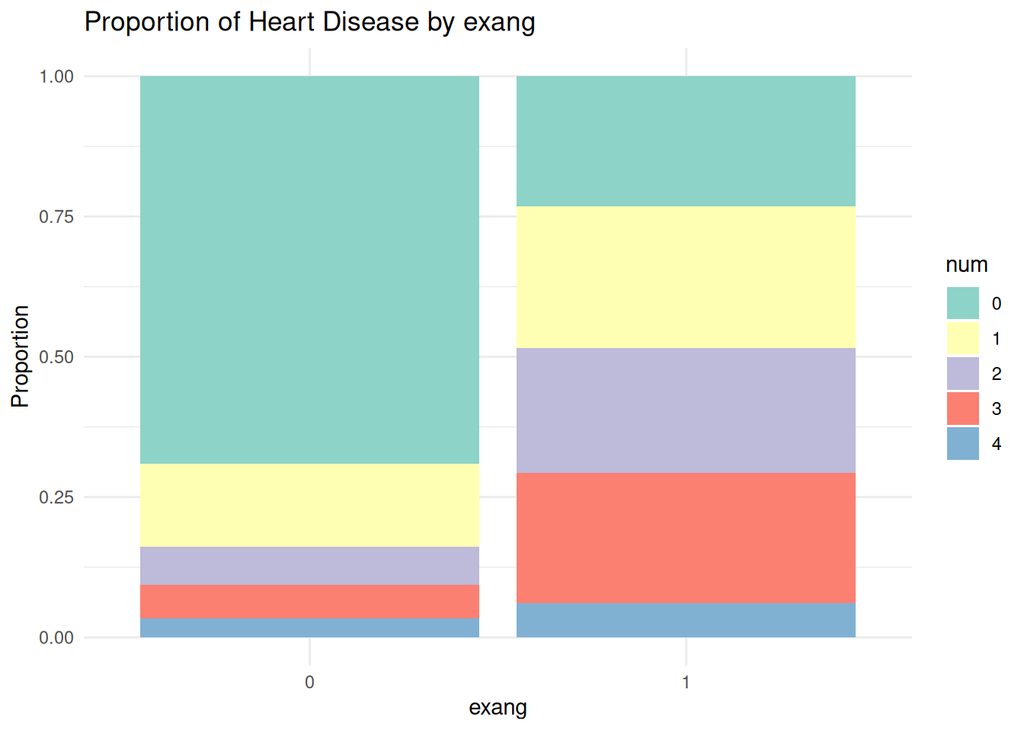

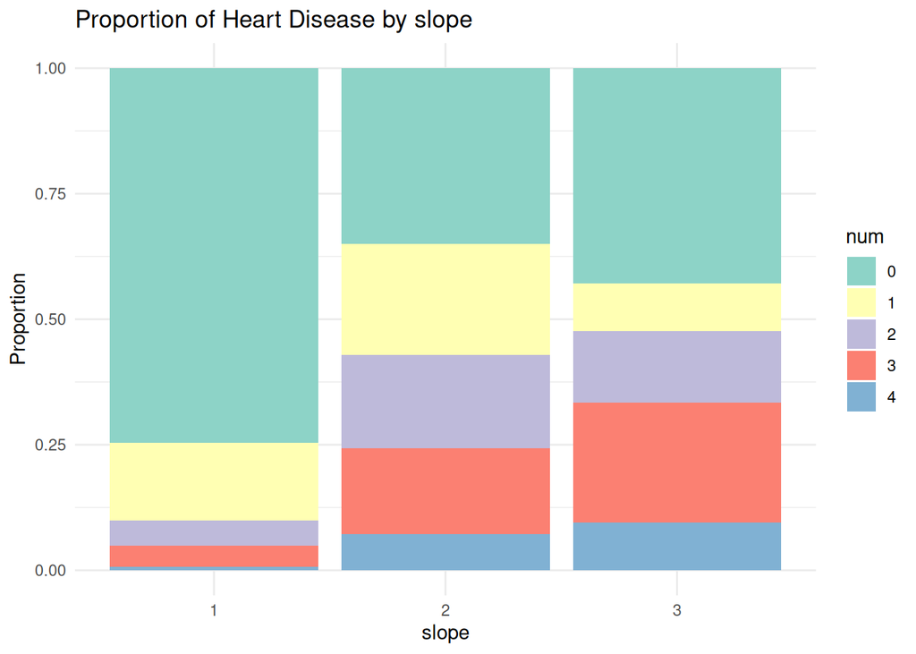

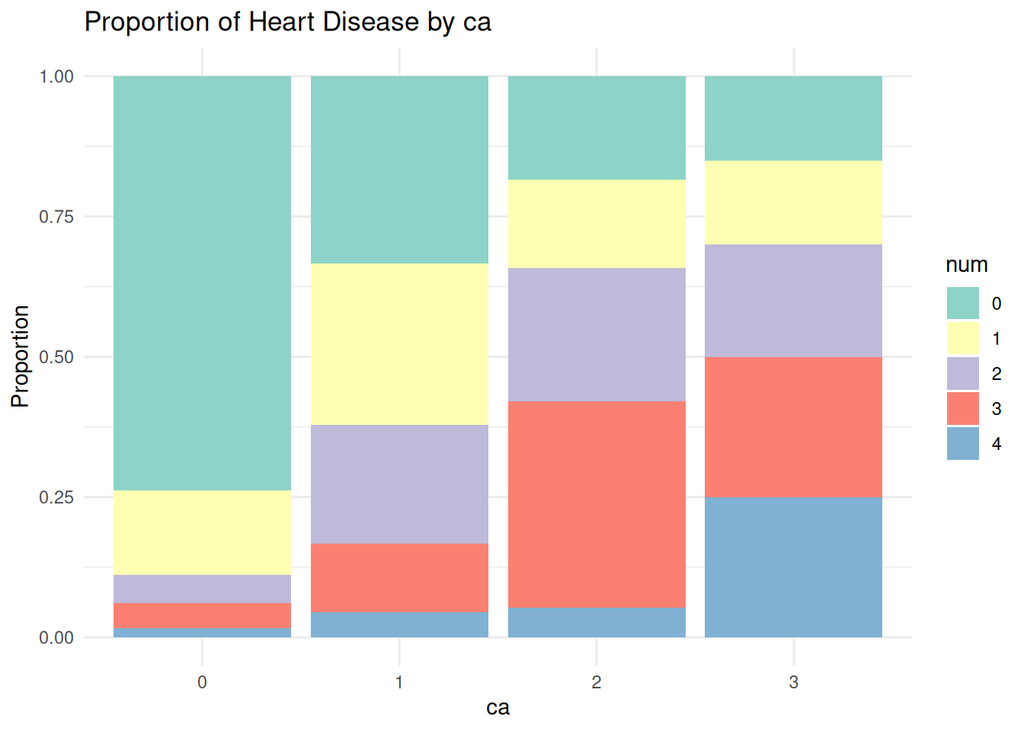

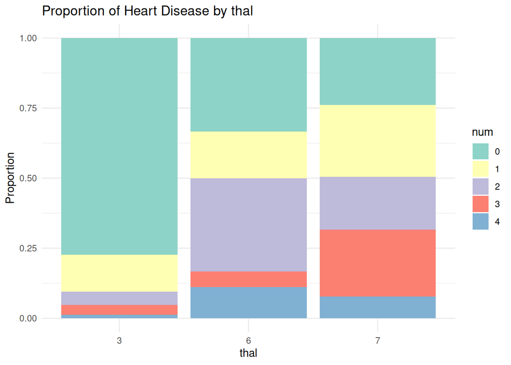

```r
# 7. Association between variables and heart disease
# Chi-squared test and filtering significant variables
significant_categorical_vars <- c()

for (col in setdiff(factor_columns, "num")) {
  chisq_test <- chisq.test(table(data_cleaned[[col]], data_cleaned$num))
  p_value <- chisq_test$p.value

  if (p_value < 0.05) {
    significant_categorical_vars <- c(significant_categorical_vars, col)
  }
}

# Ensure 'num' is a factor for proper grouping
data_cleaned$num <- as.factor(data_cleaned$num)

# Plot only significant categorical variables
for (col in significant_categorical_vars) {
  p <- ggplot(data_cleaned, aes(x = !!sym(col), fill = num)) +
    geom_bar(position = "fill") +
    labs(title = paste("Proportion of Heart Disease by", col),
         x = col, y = "Proportion") +
    theme_minimal() +
    scale_fill_brewer(palette = "Set3")
  print(p)
}
```

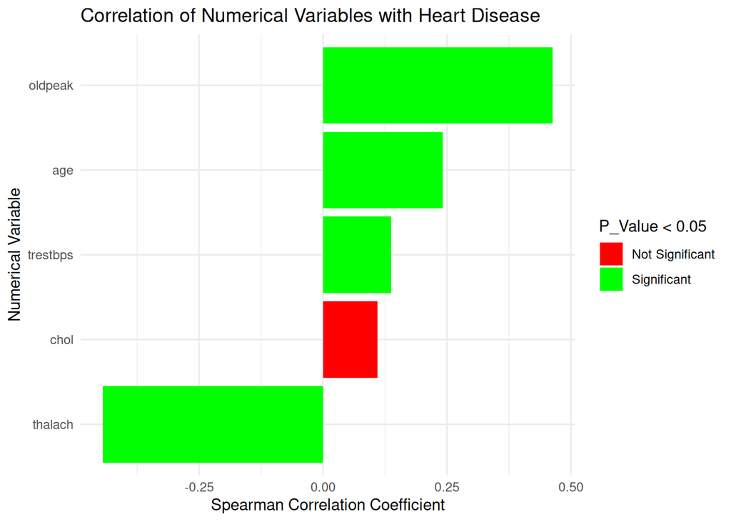

```r
# Calculate correlations and their p-values for numerical variables vs. heart disease

correlation_results <- data.frame(Variable = character(), Correlation = numeric(), P_Value = numeric())

for (col in numerical_columns) {
  if (is.numeric(data_cleaned[[col]])) {
    cor_test <- cor.test(data_cleaned[[col]], as.numeric(data_cleaned$num), method = "spearman", exact = FALSE)
    correlation_results <- rbind(correlation_results,
                                  data.frame(Variable = col,
                                             Correlation = cor_test$estimate,
                                             P_Value = cor_test$p.value))
  }
}


# Visualize the correlation coefficients and their significance
ggplot(correlation_results, aes(x = reorder(Variable, Correlation), y = Correlation, fill = P_Value < 0.05)) +
  geom_bar(stat = "identity") +
  scale_fill_manual(values = c("red", "green"), labels = c("Not Significant", "Significant")) +
  labs(title = "Correlation of Numerical Variables with Heart Disease",
       x = "Numerical Variable",
       y = "Spearman Correlation Coefficient") +
  coord_flip() +
  theme_minimal()
```

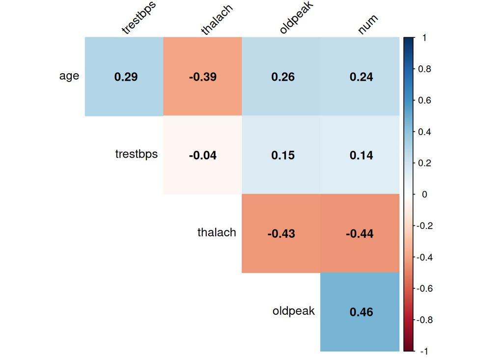

```r
# Store correlation results in a dataframe efficiently
correlation_results <- data.frame(Variable = character(), Correlation = numeric(), P_Value = numeric())

for (col in numerical_columns) {
  if (is.numeric(data_cleaned[[col]])) {
    cor_test <- cor.test(data_cleaned[[col]], as.numeric(data_cleaned$num), method = "spearman", exact = FALSE)
    correlation_results <- rbind(correlation_results,
                                  data.frame(Variable = col,
                                             Correlation = cor_test$estimate,
                                             P_Value = cor_test$p.value))
  }
}

# Filter only significant variables (p < 0.05)
significant_vars <- correlation_results %>%
  filter(P_Value < 0.05) %>%
  pull(Variable)

# Ensure heart disease variable "num" is included
significant_vars <- c(significant_vars, "num")

# Ensure 'num' is numeric
data_cleaned$num <- as.numeric(as.character(data_cleaned$num))

# Compute correlation matrix only for significant numerical variables
cor_matrix_filtered <- cor(data_cleaned[significant_vars], method = "spearman", use = "pairwise.complete.obs")

# Visualize the filtered correlation matrix
corrplot(cor_matrix_filtered, method = "color", type = "upper",
         tl.col = "black", tl.srt = 45, # Rotate labels for better readability
         addCoef.col = "black", # Show correlation coefficient values
         diag = FALSE) # Hide diagonal (correlation of variables with themselves)
```

As for the continuous variables, the correlation matrix obtained with the significant Spearman’s correlation results shows that oldpeak is the most positively associated variable with num, and that a increase in the thalach variable decreases the severity of the disease.

# 2 Difference in mortality rates in hospitalized COVID-19 patients

*Using the supplementary material from the [Difference in mortality rates in hospitalized COVID-19 patients identified by cytokine profile clustering using a machine learning approach: An outcome prediction alternative](https://www.frontiersin.org/articles/10.3389/fmed.2022.987182/full), perform the following tasks*

## Reproduce Figure 1 from the publication

```r
# Load the datasets
file1 <- "./data/raw_data/Table_1_COVID-19.XLSX"

data1 <- read_excel(file1)

# Replace the headers of data1 with the first row
colnames(data1) <- data1[1, ]  # Set the first row as column names
data1 <- data1[-1, ]           # Remove the first row

# Replace "NI" and "ND" with NA in all columns of data1
data1[data1 == "NI" | data1 == "ND"] <- NA

# Remove exact duplicates
data1 <- data1 %>%
  distinct()

# Remove duplicated IDs with different data
data1 <- data1 %>%
  group_by(ID) %>%
  filter(n() == 1) %>%
  ungroup()

# Remove rows with the Death value being different than Yes or No
data1 <- data1 %>%
  filter(!is.numeric(as.numeric(Death)) | Death %in% c("Yes", "No"))

# Iterate over each row to apply the conditions
data1$`ARDS Diagnosis` <- ifelse(
  !(data1$`ARDS Diagnosis` %in% c("Yes", "No")),  # Check if ARDS Diagnosis is not "Yes" or "No"
  ifelse(data1$`Days with ARDS` == 0, "No", "Yes"),  # If Use of ARDS is 0, set Diagnosis to "No", else "Yes"
  data1$`ARDS Diagnosis`  # Keep the existing value if ARDS Diagnosis is already "Yes" or "No"
)

data1$`Use of NIV` <- ifelse(
  !(data1$`Use of NIV` %in% c("Yes", "No")),  # Check if ARDS Diagnosis is not "Yes" or "No"
  ifelse(data1$`Days with NIV` == 0, "No", "Yes"),  # If Use of ARDS is 0, set Diagnosis to "No", else "Yes"
  data1$`Use of NIV`  # Keep the existing value if ARDS Diagnosis is already "Yes" or "No"
)

# Create the clinical groups
# Example: Assign groups based on a column (e.g., "age")
# Add clinical_class column based on conditions
data1 <- data1 %>%
  mutate(clinical_class = case_when(
    `Use of NIV` == "No" & `Use of AMV` == "No" & `ARDS Diagnosis` == "No" ~ "G1",
    `Use of NIV` == "Yes" & `Use of AMV` == "No" & `ARDS Diagnosis` == "Yes" ~ "G3",
    `Use of AMV` == "Yes" & `ARDS Diagnosis` == "Yes" ~ "G4",
    TRUE ~ "G2"  # Default case for unmatched rows
  ))

# Save processed data
write.csv(data1, "./data/processed_data/Table_1_COVID-19_processed.csv", row.names = FALSE)
```

This dataset contains clinical and cytokine data from 199 hospitalized COVID-19 patients with 19 columns.

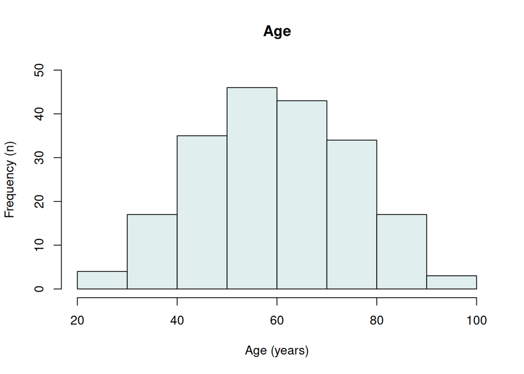

```r
# --- Reproduce the Figure ---

#### Plot 1: Age Histogram (Top-Left)
data1$Age <- as.numeric(data1$Age)
age_histogram <- hist(data1$Age,
         breaks = seq(20, 100, by = 10),
         col = "#e0eeee",
         border = "black",
         main = "Age",
         xlab = "Age (years)",
         ylab = "Frequency (n)",
         ylim = c(0, 50),
         axes = TRUE)
```

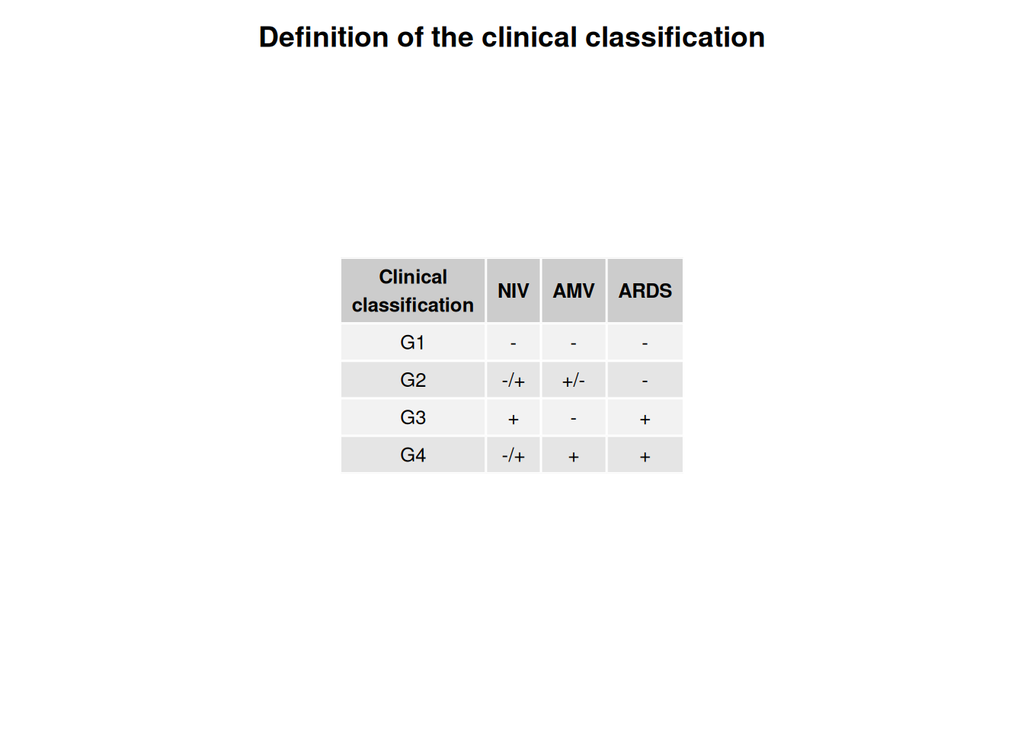

```r
#### Plot 2: Clinical Classification Table (Top-Right)
# Create the table with 4 columns and 4 rows
table_1B <- data.frame(matrix(ncol = 4, nrow = 4))

# Assign the column names to the table
colnames(table_1B) <- c("Clinical\nclassification", "NIV", "AMV", "ARDS")

# Set the corresponding values
table_1B[1,] <- c("G1", "-", "-", "-")
table_1B[2,] <- c("G2", "-/+", "+/-", "-")
table_1B[3,] <- c("G3", "+", "-", "+")
table_1B[4,] <- c("G4", "-/+", "+", "+")

# Create table with improved formatting
table_1B <- tableGrob(table_1B,
                     rows = NULL,
                     theme = ttheme_default(
                         core = list(fg_params=list(cex = 0.8)),
                         colhead = list(fg_params=list(cex = 0.8))))
grid::grid.newpage()  # Start a new plotting page
grid::grid.draw(table_1B)  # Draw the table
grid::grid.text("Definition of the clinical classification", y = 0.95, gp = gpar(fontsize = 14, fontface = "bold"))
```

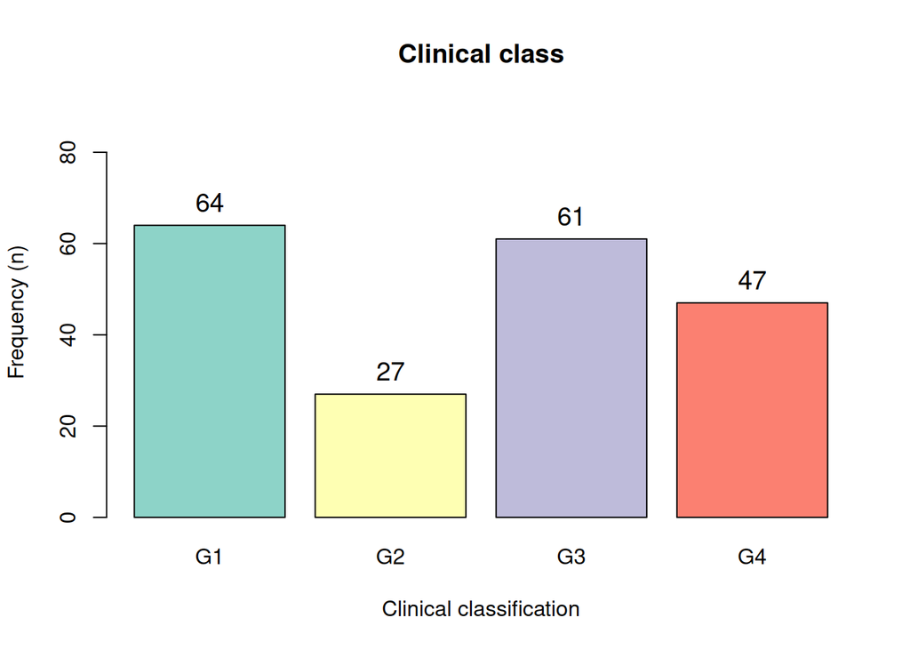

```r
#### Plot 3: Clinical class barplot (Bottom-Left)
clinical_class_plot <-mids <- barplot(table(data1$clinical_class),
                    col = c("#8dd3c8", "#feffb3", "#bebbda", "#fb8071"),
                    main = "Clinical class",
                    xlab = "Clinical classification",
                    ylab = "Frequency (n)",
                    ylim = c(0, 90))

    text(x = mids,
         y = table(data1$clinical_class) + 5,
         labels = table(data1$clinical_class),
         cex = 1.2)
```

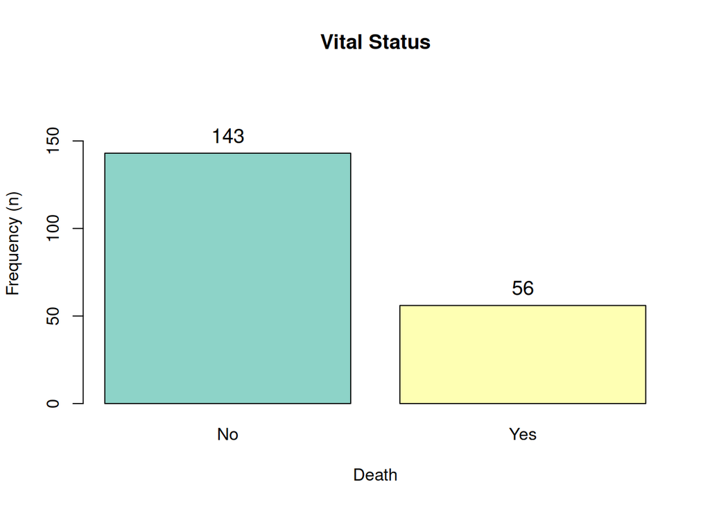

```r
#### Plot 4: Vital Status barplot (Bottom-Right)
death_plot <-mids <- barplot(table(data1$Death),
                    col = c("#8dd3c8", "#feffb3"),
                    main = "Vital Status",
                    xlab = "Death",
                    ylab = "Frequency (n)",
                    ylim = c(0, max(table(data1$Death)) + 40))

    text(x = mids,
         y = table(data1$Death) + 10,
         labels = table(data1$Death),
         cex = 1.2)
```

```r
### We tried to put the plots together using these and transforming the rbase plots to ggplots (with as.ggplot function), but it didn't work

# wrap_elements(panel = age_histogram, clip = FALSE) +
#   table_1B +
#   wrap_elements(panel = clinical_class_plot, clip = FALSE) +
#   wrap_elements(panel = death_plot, clip = FALSE) +
#   plot_annotation(tag_levels = 'A') # Tag plots
```

## Reproduce Figure 2 from the publication

*but instead of representing the clusters in the annotation, represent the groups (G1 to G4)*

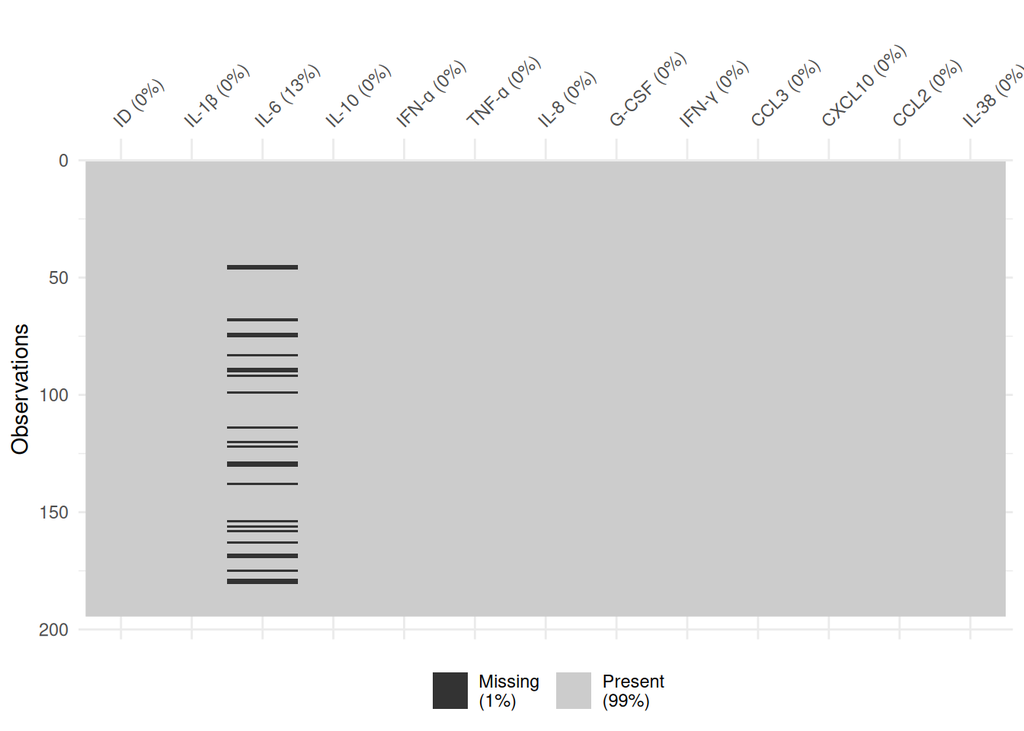

```r
# Data import and initial processing
file2 <- "./data/raw_data/Table_2_COVID-19.XLSX"
data2 <- read_excel(file2)

# Clean column headers
colnames(data2)[-1] <- data2[1, -1]  # Replace all but the first column
data2 <- data2[-1, ]                # Remove the first row

# Fill missing values in ID column
data2 <- data2 %>%
  fill(ID, .direction = "down")

# Replace "NI" with NA
data2[data2 == "NI"] <- NA

# Remove unnecessary columns
data2 <- data2[ ,-2] #Remove Day column
data2 <- data2[, -((ncol(data2)-12):ncol(data2))]

# Convert columns to numeric
data2 <- data2 %>%
  mutate(across(-ID, ~ as.numeric(.), .names = "{col}"))

# Process duplicated IDs
data2_processed <- data2 %>%
  group_by(ID) %>%
  summarise(across(everything(), ~ mean(.x, na.rm = TRUE))) %>%
  mutate(across(-ID, ~ round(., 4)))

# Replace NaN with NA
data2_processed[is.nan(data2_processed)] <- NA

# View missing values
vis_miss(data2_processed)
```

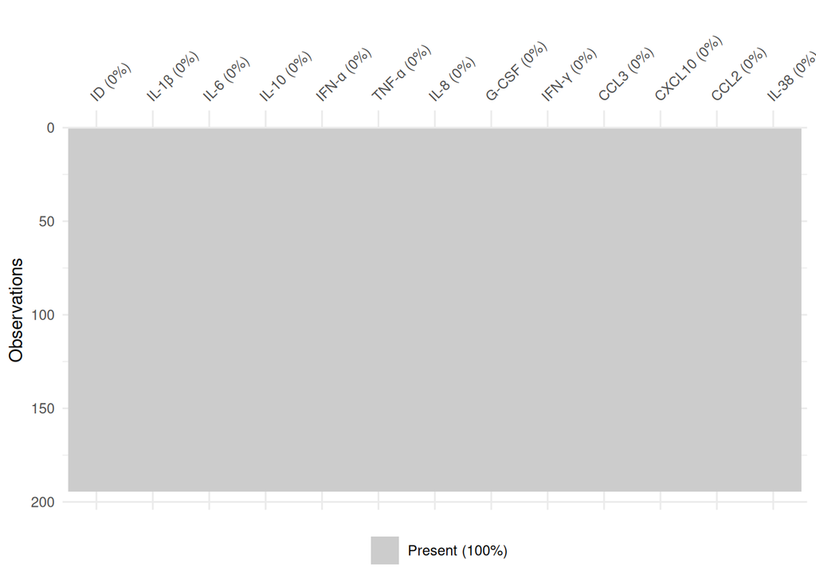

```r
# Impute missing values
imputation <- mice(data2_processed, method = "pmm", m = 5)
data2_processed <- complete(imputation)

# Check there are any missing values
vis_miss(data2_processed)
```

```r
# Fix ID mistakes
data2_processed$ID <- gsub("COAG-HSDJ-", "COAG-HSJD-", data2_processed$ID)

# Merge with clinical classes
data2_processed <- merge(data2_processed, data1[, c("ID", "clinical_class")], by = "ID", all.x = TRUE)

# Save processed data
write.csv(data2_processed, "./data/processed_data/Table_2_COVID-19_processed.csv", row.names = FALSE)
```

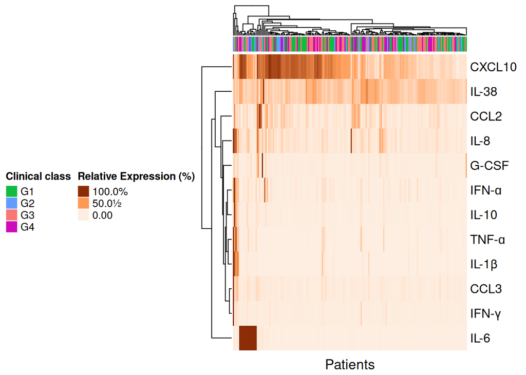

```r
# ---- Reproduce Heatmap Figure ---

# Select the cytokines and convert to numeric
cytokines <- data2_processed[, c("IL-1β", "IL-6",  "IL-10", "IFN-ɑ", "TNF-ɑ", "IL-8", "G-CSF", "IFN-γ", "CCL3", "CXCL10", "CCL2", "IL-38")]
cytokines <- as.data.frame(lapply(cytokines, as.numeric))

# Process row annotations
row_ann <- data2_processed$clinical_class
names(row_ann) <- data2_processed$ID

# Remove rows with missing annotations
valid_rows <- !is.na(row_ann)
cytokines_clean <- cytokines[valid_rows, ]
row_ann_clean <- row_ann[valid_rows]

#Normalize data (0-100 scale)
cytokines_clean <- as.data.frame(lapply(cytokines_clean, function(x) {
  x <- x / max(x, na.rm = TRUE) * 100
}))

#Create annotation dataframe
ann_df <- data.frame(ClinicalClass = row_ann_clean)
rownames(cytokines_clean) <- rownames(ann_df)

# Prepare matrix for heatmap
cytokines_clean <- t(cytokines_clean)
ann_df_order <- ann_df[order(ann_df$ClinicalClass), , drop = FALSE]
cytokines_clean_order <- cytokines_clean[, rownames(ann_df_order)]

#Fix cytokine names
rownames(cytokines_clean_order) <- gsub("\\.", "-", rownames(cytokines_clean_order))

#Define annotation colors
group_colors <- list(ClinicalClass = c(
  "G1" = "#0fbc40",
  "G2" = "#629cff",
  "G3" = "#f87772",
  "G4" = "#cd0bbc"
))

#Create top annotation
top_anno <- HeatmapAnnotation(
  ClinicalClass = ann_df_order$ClinicalClass,
  col = group_colors,
  show_annotation_name = FALSE,
  annotation_legend_param = list(
    ClinicalClass = list(
      title = "Clinical class",
      at = c("G1", "G2", "G3", "G4")
    )
))

# We tried to have the same order as in the original Figure, but it didn't work.
# cyt_order <- c("IL.6", "CXCL10", "IL.38", "IL.8", "IFN.ɑ", "IL.10", "TNF.ɑ", "CCL2", "CCL3", "IFN.γ", "IL.1β", "G.CSF")
# cytokines_clean_order <- cytokines_clean_order[cyt_order, ]

#Create heatmap
heatmap1 <- Heatmap(cytokines_clean_order,
        name = "Relative Expression",
        col = colorRamp2(c(0, 50, 100), colors = c("#fdeee1", "#fc9a55", "#8c2c06")),
        cluster_rows = TRUE,
        cluster_columns = TRUE,
        top_annotation = top_anno,
        show_row_names = TRUE,
        show_column_names = FALSE,
        row_names_side = "right",
        column_title = "Patients",
        column_title_side = "bottom",
        heatmap_legend_param = list(
           title = "Relative Expression (%)",
           at = c(0, 50, 100),
           labels = c("0.00", "50.0½", "100.0%"),
           color_bar = "discrete"
           )
)

# Draw final heatmap
draw(heatmap1,
  heatmap_legend_side = "left",
  annotation_legend_side = "left")
```

## Improve figure 2 of the publication

*Add a second annotation with information of deaths and a third one with information of gender*

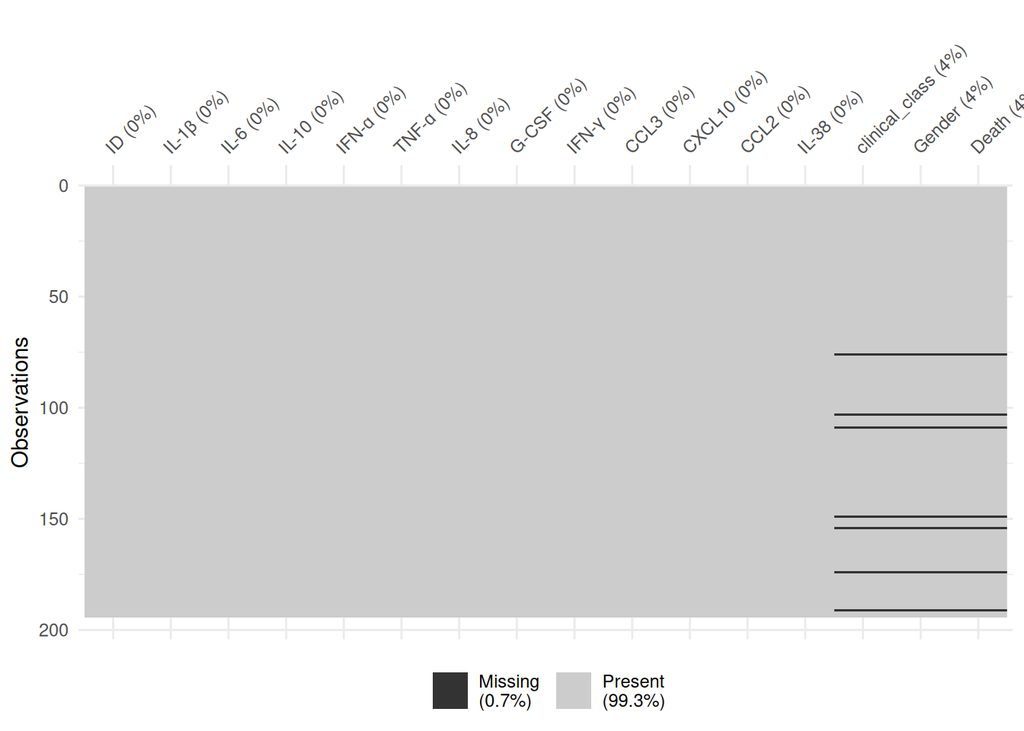

```r
# Merge the data with metadata
data2_processed_meta <- merge(data2_processed, data1[, c("ID", "Gender", "Death")], by = "ID", all.x = TRUE)

# Check for missing data
vis_miss(data2_processed_meta)
```

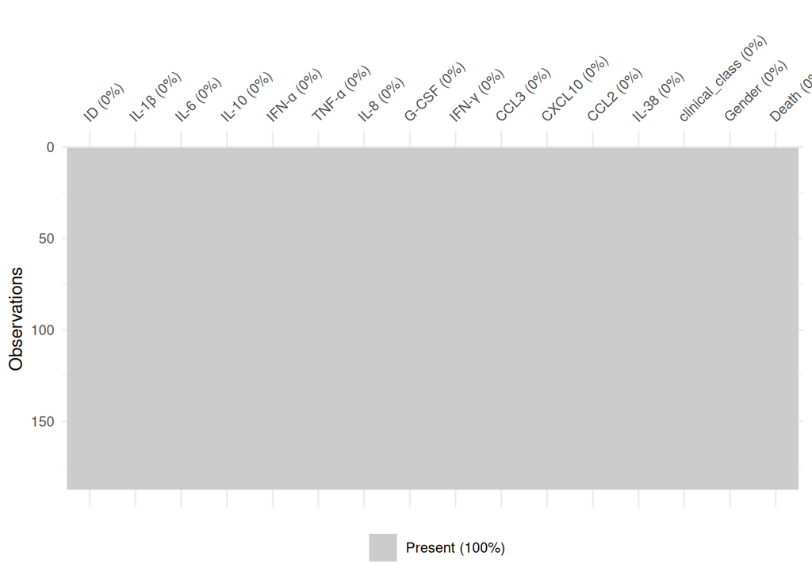

```r
# Filter out rows with NA in key columns
data2_processed_meta <- data2_processed_meta %>%
  filter(!is.na(Gender) & !is.na(Death) & !is.na(clinical_class))

# Verify no missing data remains
vis_miss(data2_processed_meta)
```

```r
# Remove the specific row where Gender is 72
data2_processed_meta <- data2_processed_meta[data2_processed_meta$Gender %in% c("M", "F"), ]

# Save merged data with processed data plus metadata
write.csv(data2_processed_meta, "./data/processed_data/Table_2_COVID-19_processed_with_metadata.csv", row.names = FALSE)
```

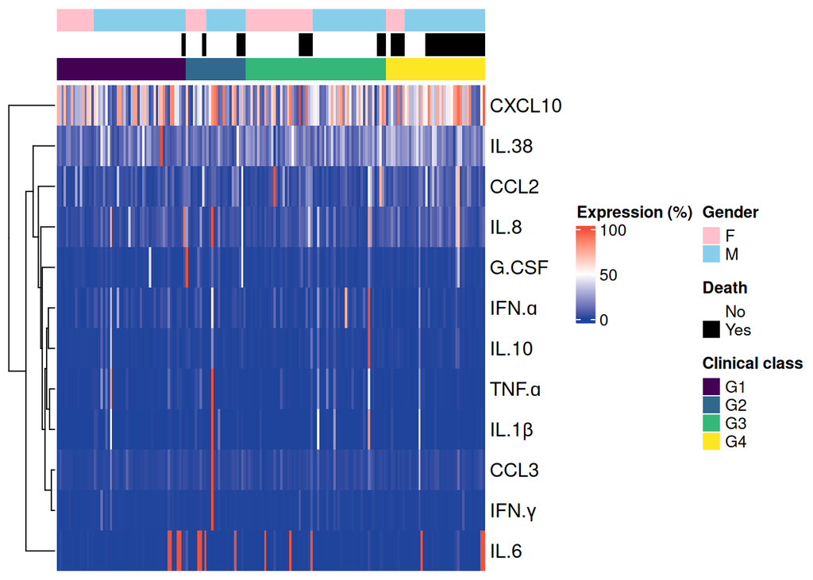

```r
# Select cytokine columns and convert to numeric
cytokines2 <- data2_processed_meta[, c("IL-1β", "IL-6", "IL-10", "IFN-ɑ",
                                      "TNF-ɑ", "IL-8", "G-CSF", "IFN-γ",
                                      "CCL3", "CXCL10", "CCL2", "IL-38")]
cytokines2 <- as.data.frame(lapply(cytokines2, as.numeric))

# Create matrix for heatmap
cytokine2_matrix <- as.matrix(cytokines2)
rownames(cytokine2_matrix) <- data2_processed_meta$ID

# Normalize the data (0-100 scale)
cytokine2_matrix_norm <- apply(cytokine2_matrix, 2, function(x) {
  (x - min(x, na.rm = TRUE)) / (max(x, na.rm = TRUE) - min(x, na.rm = TRUE)) * 100
})

# Create a new ordered factor for clinical_class to ensure specific order
data2_processed_meta$clinical_class <- factor(data2_processed_meta$clinical_class, levels = c("G1", "G2", "G3", "G4"))

# Create column annotation
col_anno2 <- HeatmapAnnotation(
  Gender = factor(data2_processed_meta$Gender),
  Death = factor(data2_processed_meta$Death),
  ClinicalClass = factor(data2_processed_meta$clinical_class),
  col = list(
    Gender = c("F" = "pink", "M" = "skyblue"),
    Death = c( "No" = "white", "Yes" = "black"),
    ClinicalClass = c(
    "G1" = viridis(4)[1],
    "G2" = viridis(4)[2],
    "G3" = viridis(4)[3],
    "G4" = viridis(4)[4]
  )),
  show_annotation_name = FALSE,
  annotation_legend_param = list(
    ClinicalClass = list(title = "Clinical class")
  )
)

# Create and display the heatmap
heatmap2 <- Heatmap(
    t(cytokine2_matrix_norm),
    name = "Expression (%)",
    col = colorRamp2(c(0, 50, 100), c("#1F449C", "white", "#F05039")),
    top_annotation = col_anno2,
    show_row_names = TRUE,
    show_column_names = FALSE,
    cluster_rows = TRUE,
    cluster_columns = FALSE,
    column_title = NULL,
    column_order = order(
      data2_processed_meta$clinical_class,
      data2_processed_meta$Gender,
      data2_processed_meta$Death
    ),
    heatmap_legend_param = list(
        at = c(0, 50, 100),
        labels = c("0", "50", "100"),
        title = "Expression (%)"
    )
)

# Draw the heatmap
draw(heatmap2)
```

# session info

R version 4.4.2 (2024-10-31) Platform: x86_64-pc-linux-gnu Running under: Ubuntu 24.04.2 LTS

Matrix products: default BLAS: /usr/lib/x86_64-linux-gnu/blas/libblas.so.3.12.0 LAPACK: /usr/lib/x86_64-linux-gnu/lapack/liblapack.so.3.12.0

locale: [1] LC_CTYPE=en_US.UTF-8 LC_NUMERIC=C  
[3] LC_TIME=en_US.UTF-8 LC_COLLATE=en_US.UTF-8  
[5] LC_MONETARY=en_US.UTF-8 LC_MESSAGES=en_US.UTF-8  
[7] LC_PAPER=en_US.UTF-8 LC_NAME=C  
[9] LC_ADDRESS=C LC_TELEPHONE=C  
[11] LC_MEASUREMENT=en_US.UTF-8 LC_IDENTIFICATION=C

time zone: Europe/Madrid tzcode source: system (glibc)

attached base packages: [1] grid stats graphics grDevices utils datasets methods  
[8] base

other attached packages: [1] viridis_0.6.5 viridisLite_0.4.2 tibble_3.2.1  
[4] circlize_0.4.16 ComplexHeatmap_2.20.0 naniar_1.1.0  
[7] patchwork_1.3.0 ggplotify_0.1.2 gridExtra_2.3  
[10] readxl_1.4.3 corrplot_0.95 rcompanion_2.4.36  
[13] ggpubr_0.6.0 reshape2_1.4.4 dplyr_1.1.4  
[16] tidyr_1.3.1 mlbench_2.1-6 vtable_1.4.8  
[19] kableExtra_1.4.0 SmartEDA_0.3.10 DataExplorer_0.8.3  
[22] GGally_2.2.1 ggplot2_3.5.1 mice_3.17.0